### 11월/2주

#### ▶ ▣ 정당지지도 ▣

더불어민주당 46.4%, 국민의힘 35.7%, 정의당 2.1%, 기타 정당 3.0%, 지지하는 정당이 없다 12.1%, 잘 모르겠다 0.8%

#### ▶ ▣ 대통령 국정 수행 평가 ▣

잘하고 있다 35.9%, 잘못하고 있다 62.2%, 잘 모르겠다 1.9%

#### ☑ ▣ 총선 프레임 공감 ▣

원활한 국정수행을 뒷받침하기 위해 여당인 국민의힘에 힘을 실어 줘야 한다 33.6%, 현 정권 견제를 위해서 제1야당인 민주당에 힘을 실어 줘야 한다 50.2%, 기존 양당이 아닌 제3세력에 힘을 실어 줘야 한다 16.1%

#### ☑ ▣ 김건희 특검 공감도 ▣

매우 공감한다 56.2%, 어느 정도 공감한다 7.7%, 별로 공감하지 않는다 16.8%, 전혀 공감하지 않는다 17.1%, 잘 모르겠다 2.3%

#### ☑ ▣ 메가서울 정책 찬반 ▣

매우 찬성한다 20.9%, 찬성하는 편이다 11.6%, 반대하는 편이다 15.0%, 매우 반대한다 47.5%, 잘 모르겠다 5.0%

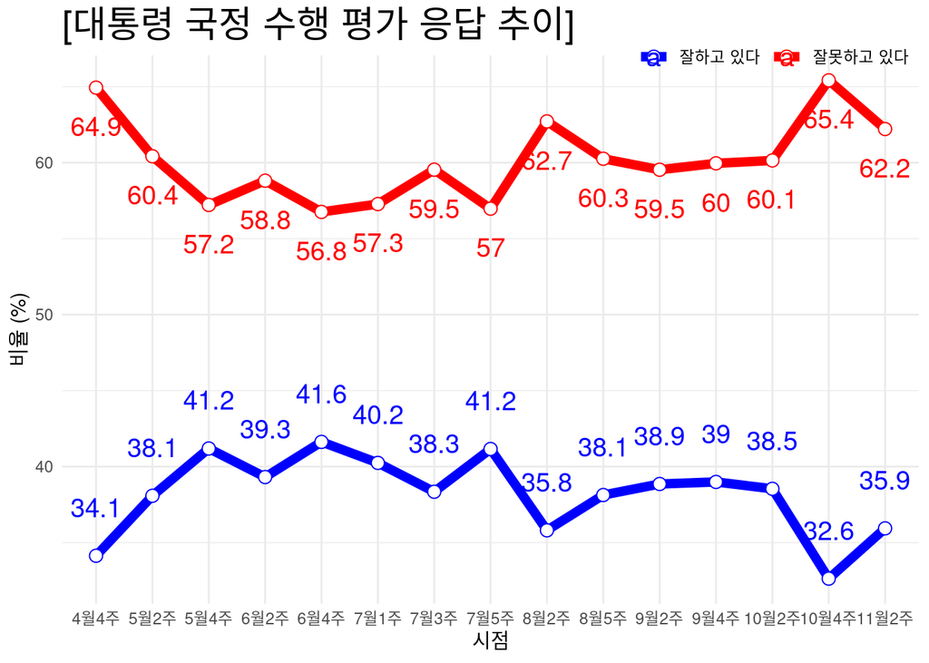

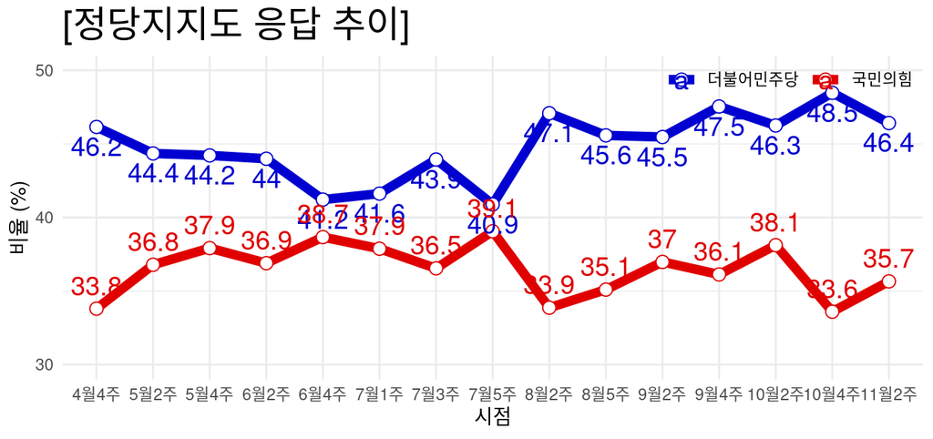

### 추가사항

- [주요질문 / 집단별 세부통계 보기](https://modernity.shinyapps.io/survey_str/) (링크누르시오)

### 참고사항

- 표본수: 2,000명,표본오차는 95% ±2.2%p
- 조사정보: 스트레이트뉴스의 의뢰로 조원씨앤아이가 2023년 11월 4~6일 3일간

  전국 만 18세 이상 남녀를 대상으로 ARS 여론조사

  (휴대전화 100% RDD 방식, 성,연령대,지역별 비례할당 후 무작위 추출)를 실시한 결과이며,

  표본수는 2,000(총 통화시도 76,643명, 응답률 2.6%)

  ※ 가중치 부여 방식: [림가중] 성별, 연령별, 지역별 가중값 부여(2023년 10월말 행정안전부 발표 주민등록인구기준)
- [중앙선거여론조사심의위원회](https://nesdc.go.kr/portal/bbs/B0000005/list.do?menuNo=200467)에서 관련사항 확인가능

2023.11.10 (금) 10:29 제작

- 연구개발 단계입니다.
- 제공: 감동과 마음의 [조원씨앤아이](http://jowoncni.com/html/index.html)